# Differences and similarities between blandr.stats and Bland-Lehman stats

2021/08_15

```r
library(captioner)
library(cowplot)
library(BlandAltmanLeh)
library(blandr)
library(dplyr)
library(ggdist)
library(ggExtra)
library(ggpubr)
library(ggplot2)
library(ggthemes)
library(janitor)
library(kableExtra)
library(knitr)
library(purrr)
library(qqplotr)
library(readr)
library(tidyquant)
library(tidyr)
library(tidyverse)
library(zeallot)


source("/Volumes/InmanDrive4/Dropbox/Dropbox/KPI/University_of_Dundee/Dissertation/Lab Notebooks/library.R")
```

#### *Purpose*

I have noticed that there seems to be a difference between the upper and lower limits of agreement (LoA) between the custom function that I wrote for a bland-altman plot and those limits as calculated in the blandr package.

Specifically, my plot uses the statistics derived from the BlandAltmanLeh package, which is called from *‘bland.altman.stats’* function, while I have, as legacy code, performed a data integrity check using the blandr.stats function. A check of the LoA versus upper and lower limits, and what is graphed, shows difference.

This notebook explores the source of the difference.

Start with using data from the BlandAltman_EFM_likeLTD_ston_plotsv2.Rmd file.

```r
# Create dataframe and extract specific data for Bland Altman analysis

MT <- read.csv("/Volumes/InmanDrive4/Dropbox/Dropbox/KPI/University_of_Dundee/Dissertation/Data/Output_files/AllResults_Data/AllResults_Table.csv")

MT$TotDNA <- as.factor(MT$TotDNA) # Need to turn the TotDNA into a factor (rather than integer) in order to plot using it as a group in ggplot (integer can't be used to group values, unless binning them). Before writing this step, I got an error in later code that MT$DNA did not exist, which of course it did. Finally realized you can't group by integers.
```

#### Subset dataframe with LR from one program (including columns needed for the subsetting task)

For this analysis, I will use both the efficiency and the logLR. They should show the same thing, inasmuch as the differences are calculated on the sample/program/POI, and there should be no differences based on the contributor RMP.

This first analysis is done using *efficiency*

```r
baEFM <- MT %>%
  select(Sample,Program,TotlogLR,Eff,StFilt,TCon,TotDNA) %>%
  filter(Program == "EFM",StFilt =="on")

baEFM <- na.omit(baEFM)

# Subset dataframe with LR from the other program (including columns needed for the subsetting task)
baLTD <- MT %>%
  select(Sample,Program,TotlogLR,Eff,StFilt,TCon,TotDNA) %>%
  filter(Program == "likeLTD",StFilt == "on")
baLTD <- na.omit(baLTD)
```

```r
baLR <- baEFM %>%
  inner_join(baLTD, by = c("Sample", "TCon")) %>%
  select(Sample, TotlogLR.x, TotlogLR.y, TotDNA.x, TotDNA.y)
```

```
Error in select(., Sample, TotlogLR.x, TotlogLR.y, TotDNA.x, TotDNA.y) :
  unused arguments (Sample, TotlogLR.x, TotlogLR.y, TotDNA.x, TotDNA.y)
```

Check on data to ensure integrity and adherence to proper format

```r
blandr.statsEff <- as.data.frame(blandr.statistics(baEff$Eff.x,baEff$Eff.y))
bland_Leh.stats <- bland.altman.stats(baEff$Eff.x, baEff$Eff.y)


#blandr.statsEff <- as.data.frame(blandr.statistics(baEff$Eff.x,baEff$Eff.y)) %>%
  #select(means, differences)


bland_Leh.stats <- bland.altman.stats(baEff$Eff.x, baEff$Eff.y) # Create list of B-A stats using the Bland-Lehman stats
bland_Leh.statsEff <- as.data.frame(c(bland_Leh.stats[1],bland_Leh.stats[2])) #select only those columsn with means/differences
```

```r
blandr.data <- as.data.frame(t(blandr.statsEff)) %>%
  select(1) %>%
  rename("blandr" = 1)


bland_Leh.stats <- as.data.frame(unlist(bland_Leh.stats$groups))
```

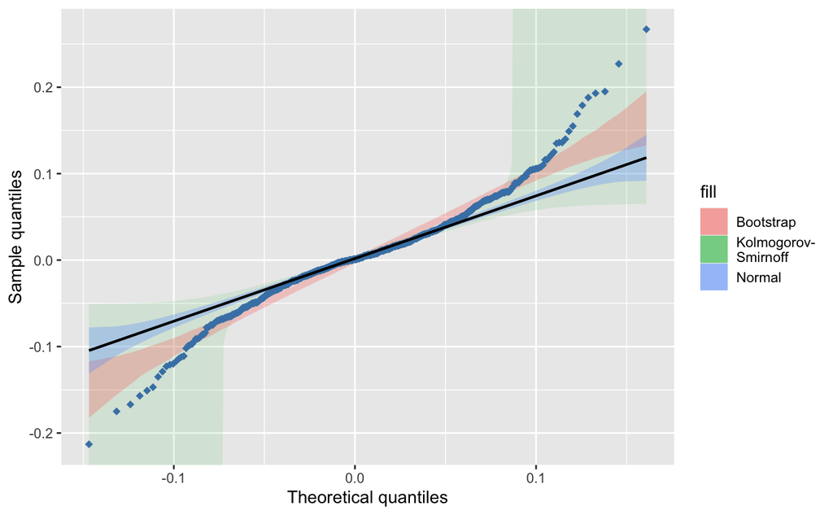

```r
gg <- ggplot(data = bland_Leh.statsEff, mapping = aes(sample = diffs)) +
  stat_qq_band(bandType = "ks", mapping = aes(fill = "Kolmogorov-\nSmirnoff"), alpha = 0.1) +
  stat_qq_band(bandType = "boot", mapping = aes(fill = "Bootstrap"), alpha = 0.3) +
  stat_qq_band(mapping = aes(fill = "Normal"), alpha = 0.3) +
  stat_qq_point(shape = 18, size =2, color = "steelblue") +
  stat_qq_line() +
  labs(x = "Theoretical quantiles", y = "Sample quantiles")

gg
```

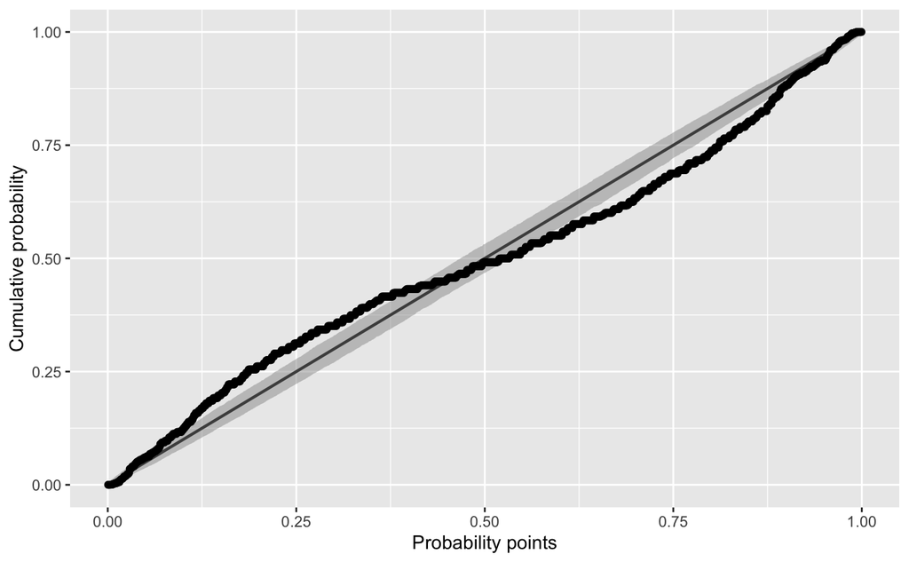

```r
gg1 <- ggplot(data = baEff_Diff, mapping = aes(sample = Diff)) +
  #stat_pp_band(bandType = "ks", mapping = aes(fill = "Kolmogorov-Smirnoff"), alpha = 0.3) +
  #stat_pp_band(bandType = "boot", mapping = aes(fill = "Bootstrap"), alpha = 0.5) +
  stat_pp_band() +
  stat_pp_line() +
  stat_pp_point() +
  labs(x = "Probability points", y = "Cumulative probability")

gg1
```

```r
baEff_Diff <- baEff %>%
  mutate(Diff = Eff.x-Eff.y) %>%
  select(1,2,3,4,6) %>%
  rename("TotDNA" = TotDNA.x)
```

```
Error in select(., 1, 2, 3, 4, 6) : unused arguments (1, 2, 3, 4, 6)
```

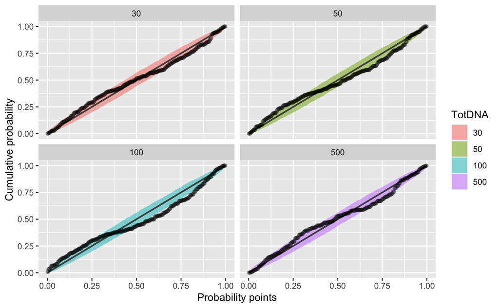

```r
gg1 <- ggplot(data = baEff_Diff, mapping = aes(sample = Diff)) +
  stat_pp_band(alpha = 0.5, mapping = aes(fill = TotDNA)) +
  stat_pp_line() +
  stat_pp_point(alpha = 0.3) +
  facet_wrap(~ TotDNA) +
  labs(x = "Probability points", y = "Cumulative probability")

gg1
```

#### Fitting a distribution to the data

Using the ‘fitdistrplus’ package, find the distribution that best describes the data.

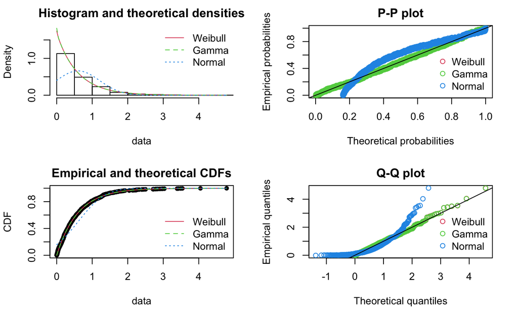